# Statistique et analyse de données en grande dimension

DS M2 Master MAS 2023-2024

**NOM : KEITA**

**PRENOM : MAHAMADOU OUSMANE**

#### Dans ce DS, il est proposé d’étudier les performances de quelques méthodes d’estimation du graphe de dépendance conditionnelle dans un modèle Gaussien à partir de données simulées. Pour un vecteur $X \sim \mathcal{N}(0,\Sigma)$, on note $X^{(i)}$ sa $i$-ème coordonnée. Dans l’ensemble du DS, on considère une matrice de précision $K = \Sigma^{-1}$ de taille $p \times p$ qui est fixée et donnée par le code ci-dessous. Vous devez exécuter ce code une seule fois avant de répondre à l’ensemble des questions. La matrice $K$ est ainsi considérée comme étant fixée.

```r
# Construction d'une matrice creuse
p = 30 # Nombre de sommets
q = 0.2 # Sparsité de la matrice
M = matrix(rbinom(p^2,size=1,prob=q), p, p)
M = (M+t(M))/2
res = eigen(M,symmetric=TRUE)

# Construction d'une matrice de précision K
# symmétrique et définie positive
K = 2*max(abs(res$values))*diag(p) + M
print(eigen(K)$values)
```

```
##  [1] 19.26998 15.71134 15.14255 15.00717 14.72183 14.55720 14.26676 14.13084
##  [9] 13.96573 13.76379 13.63465 13.38701 13.34678 13.15276 13.03698 12.84273
## [17] 12.77690 12.60988 12.43734 12.23793 12.17578 12.01762 11.79460 11.62909
## [25] 11.49955 11.09417 10.85206 10.65018 10.50448 10.18195
```

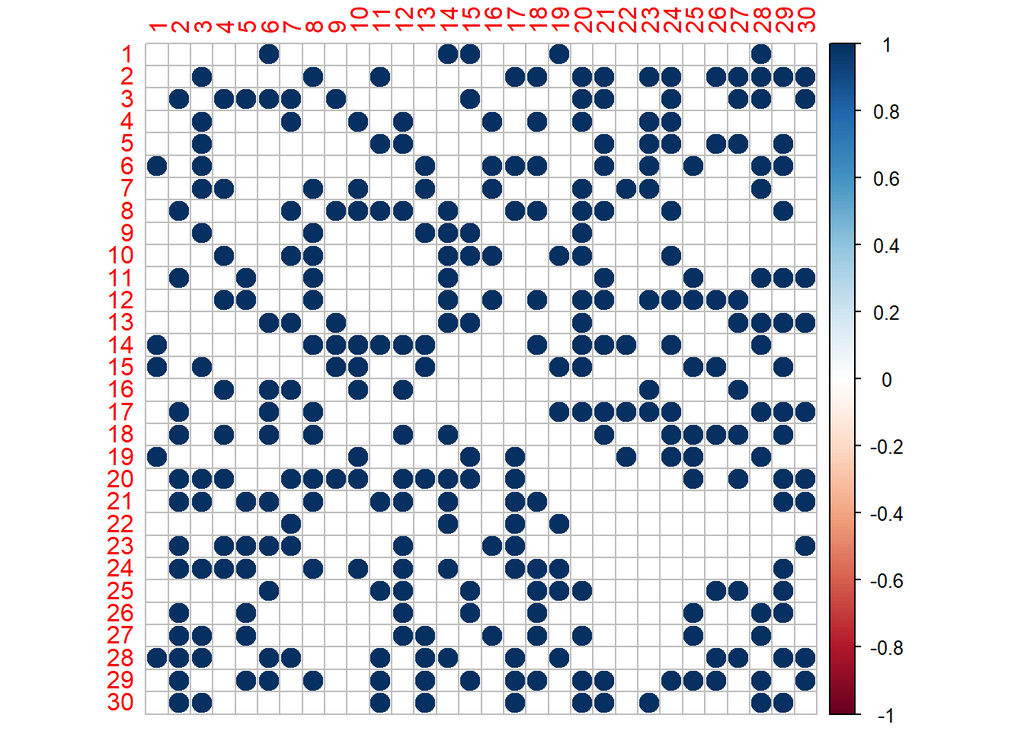

```r
# Matrice d'adjacence du graphe de dépendance conditionnelle
A = K
A[abs(A) > 0] = 1
diag(A) = 0

# Visualisation de la matrice d'ajacence asscoiée à K
library(corrplot)
corrplot(A)
```

## Question 1 - 1 pts

#### Compléter le code ci-dessous pour construire une matrice $\mathbf{X}$ de taille $n \times p$ dont les lignes sont $n=100$ réalisations iid d’un vecteur gaussien dont la matrice de précision est K

```r
library(MASS)
n = 100
Sigma = solve(K)
X = mvrnorm(n = n,Sigma = Sigma,mu =rep(0,dim(Sigma)[1]))
```

## Question 2 - 1 pts

#### Compléter le code ci-dessous pour déterminer la vraie matrice $C$ de corrélation linéaire usuelle, et la vraie matrice de corrélation conditionnelle notée $R$ entre les coordonnées du vecteur gaussien $X \sim \mathcal{N}(0,\Sigma)$.

```r
# Matrice de corrélation linéaire
D = as.matrix(diag(Sigma))
C = Sigma / sqrt((D%*%t(D)))

# Matrice de corrélation conditionnelle
D = as.matrix(diag(K))
R = -K / sqrt((D%*%t(D)))
```

## Question 3 - 1 pts

#### Compléter le code ci-dessous pour construire un estimateur $\hat{A}_{\alpha}$ de la matrice d’adjacence $A$ à partir d’une procédure de test de Student au niveau $\alpha \in [0,1]$ basée sur la significativité des coefficients de corrélation conditionnelle empirique calculés à partir de la matrice de données $\mathbf{X}$.

```r
# Estimation de la matrice de précision
###
K <- solve(cov(X))

# Estimation de la matrice de corrélation conditionnelle
###
rho<- -K/sqrt(D%*%t(D))

# Estimation de la matrice d'adjacence par test d'hypothèses
hatA_alpha = matrix(0,p,p)
alpha = 0.05
###
t <- sqrt(n-p-2)*rho/sqrt(1-rho^2)
p_value <- 2*(1-pt(abs(t), df = n-p-2))
diag(p_value) <- 0
hatA_alpha[abs(p_value) < alpha] <- 1
diag(hatA_alpha) <- 0
```

#### Exécuter le code ci-dessous pour visualiser la matrice d’ajacence estimée et évaluer la qualité de l’estimateur $\hat{A}_{\alpha}$ pour l’erreur de Frobenius $\frac{1}{p^2}\|\hat{A}_{\alpha}-A\|_F^2$

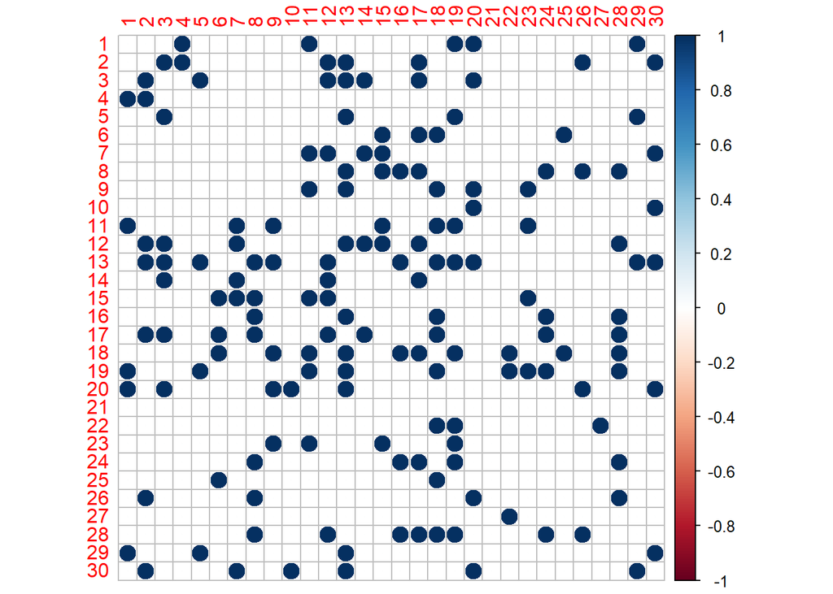

```r
library(corrplot)
corrplot(hatA_alpha)
```

```r
print(sum((hatA_alpha-A)^2)/p^2)
```

```
## [1] 0.4
```

## Question 4 - 1 pts

#### Compléter le code ci-dessous pour construire un estimateur $\hat{A}_{\lambda}$ de la matrice d’adjacence $A$ à partir de la procédure GLASSO basée sur la matrice de données $\mathbf{X}$ et pour une valeur donnée du paramètre de régularisation $\lambda$

```r
# Estimation de la matrice de précision par GLASSO
library(huge)
lambda = 0.1
glasso.res = huge(x = X, lambda = lambda,method = "glasso",verbose = F)
hatA_lambda = glasso.res$path[[1]]
```

#### Exécuter le code ci-dessous pour visualiser la matrice d’ajacence estimée et évaluer la qualité de l’estimateur $\hat{A}_{\lambda}$ pour l’erreur de Frobenius $\frac{1}{p^2}\|\hat{A}_{\lambda}-A\|_F^2$

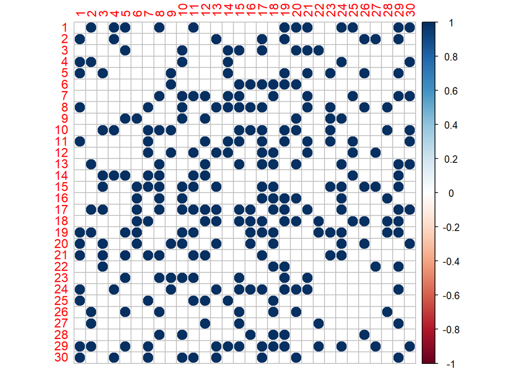

```r
library(corrplot)
corrplot(hatA_lambda)
```

```r
print(sum((hatA_lambda-A)^2)/p^2)
```

```
## [1] 0.4111111
```

## Question 5 - 0.5 pts

#### # Compléter le code ci-dessous pour déterminer quel estimateur entre $\hat{A}_{\alpha}$ (pour $\alpha = 0.05$) et $\hat{A}_{\lambda}$ (pour $\lambda = 0.1$) possède la plus petite erreur de Frobenius

```r
if (sum(diag(t(A)%*%hatA_lambda)) < sum(diag(t(A)%*%hatA_alpha))) {
  print("C'est le GLASSO")
}else{
  print("C'est la procédure par tests d'hypothèses")
}
```

```
## [1] "C'est la procédure par tests d'hypothèses"
```

#### Dans la suite, pour une liste de valeurs de $\alpha$ et une liste de valeurs de $\lambda$, on souhaite pouvoir évaluer par simulation de Monte-Carlo le risque (i.e. les erreurs moyennes) des estimateurs $\hat{A}_{\alpha}$ et $\hat{A}_{\lambda}$ défini par

$$R(\hat{A}_{\alpha},A) = \mathbb{E} \left(\frac{1}{p^2}
\|\hat{A}_{\alpha}-A\|_F^2 \right) \mbox{ et } R(\hat{A}_{\lambda},A) =
\mathbb{E} \left(\frac{1}{p^2} \|\hat{A}_{\lambda}-A\|_F^2 \right)$$
Pour cela, on va simuler $M$ réalisations $\mathbf{X}^{(1)},\ldots,\mathbf{X}^{(M)}$ de la matrice $\mathbf{X}$, et on va calculer pour chaque matrice de données $\mathbf{X}^{(m)}$ les estimateurs associés $\hat{A}_{\alpha}^{(m)}$ et $\hat{A}_{\lambda}^{(m)}$. Ensuite on aura une estimation des risques $R(\hat{A}_{\alpha},A)$ et $R(\hat{A}_{\lambda},A)$ par la loi des grands nombres
$$R(\hat{A}_{\alpha},A) \approx \frac{1}{M} \sum_{m=1}^{M}
\left(\frac{1}{p^2} \|\hat{A}_{\alpha}^{(m)}-A\|_F^2 \right) \mbox{ et }
R(\hat{A}_{\lambda},A) \approx \frac{1}{M} \sum_{m=1}^{M}
\left(\frac{1}{p^2} \|\hat{A}_{\lambda}^{(m)}-A\|_F^2 \right)$$

## Question 6 - 2.5 pts

#### # Compléter le code ci-dessous pour estimer $R(\hat{A}_{\alpha},A)$ et $R(\hat{A}_{\lambda},A)$ par simulation de Monte-Carlo pour une grille donnée de valeurs pour $\alpha$ et $\lambda$

```r
M=10
nb_param = 10

# Grille alpha
alpha_grid = seq(0.0001,0.005,length.out = nb_param)
erreur_test = rep(0,length(alpha_grid))

# Grille lambda
lambda_grid = seq(0.01,0.2,length.out = nb_param)
erreur_GLASSO = rep(0,length(lambda_grid))

for (m in 1:M){
  #print(m)
  # Génération des données
  X = mvrnorm(n=n,mu=rep(0,p),Sigma=Sigma)

  for (k in 1:nb_param){

    alpha = alpha_grid[k]
    lambda = lambda_grid[k]

    ##################################
    # Procédure de tests d'hypothèses
    ##################################

    hatA_alpha = matrix(0,p,p)
    t <- sqrt(n-p-2)*rho/sqrt(1-rho^2)
    p_value <- 2*(1-pt(abs(t), df = n-p-2))
    diag(p_value) <- 0
    hatA_alpha[abs(p_value) < alpha] <- 1
    diag(hatA_alpha) <- 0

    erreur_test[k] = erreur_test[k] + sum((hatA_alpha-A)^2)/p^2

    ##################################
    # Procédure GLASSO
    ##################################

    glasso.res = huge(x = X, lambda = lambda,method = "glasso",verbose = F)
    hatA_lambda = glasso.res$path[[1]]

    erreur_GLASSO[k] = erreur_GLASSO[k] +  sum((hatA_lambda-A)^2)/p^2

  }
}

erreur_test = erreur_test/M
erreur_GLASSO = erreur_GLASSO/M
```

## Question 7 0.5 pts

#### # Utiliser le code ci-dessous pour viualiser les estimations de $\alpha \mapsto R(\hat{A}_{\alpha},A)$ et $\lambda \mapsto R(\hat{A}_{\lambda},A)$ par simulation de Monte-Carlo.

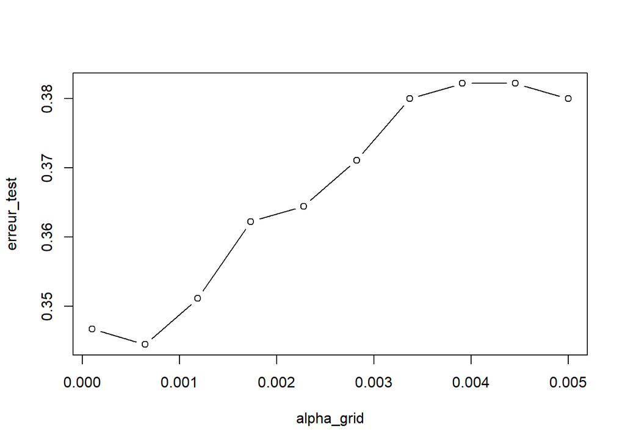

```r
plot(alpha_grid,erreur_test,type="b")
```

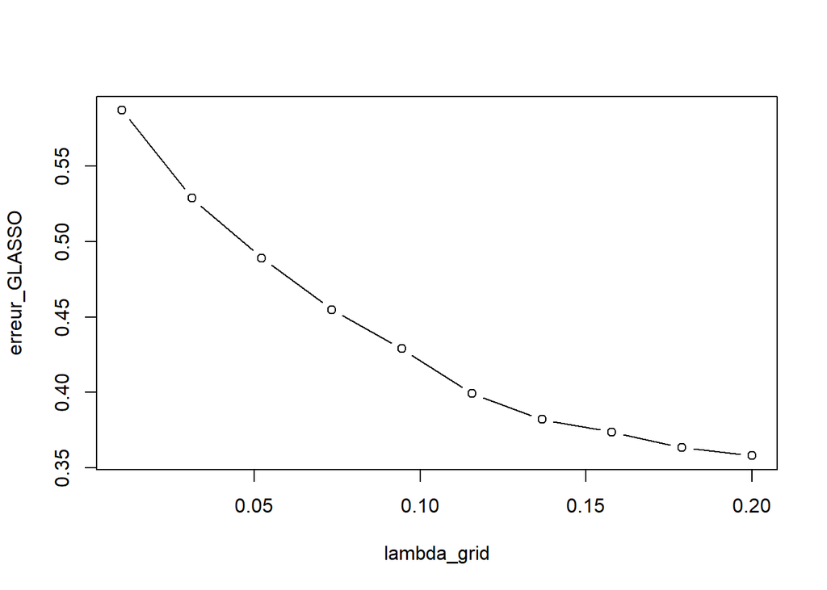

```r
plot(lambda_grid,erreur_GLASSO,type="b")
```

#### Quelle est la valeur $\alpha^\ast$ de $\alpha$ qui donne la plus petite erreur ? Quelle est la valeur $\lambda^\ast$ de $\lambda$ qui donne la plus petite erreur ? Quel est le meilleur estimateur entre $\hat{A}_{\alpha^\ast}$ et $\hat{A}_{\lambda^\ast}$ ?

```r
alpha_ast = alpha_grid[which.min(erreur_test)]
print(alpha_ast)
```

```
## [1] 0.0006444444
```

```r
lambda_ast = lambda_grid[which.min(erreur_GLASSO)]
print(lambda_ast)
```

```
## [1] 0.2
```

```r
if (sum(diag(t(A)%*%hatA_lambda)) < sum(diag(t(A)%*%hatA_alpha))) {
  print("C'est le GLASSO")
}else if (sum(diag(t(A)%*%hatA_lambda)) > sum(diag(t(A)%*%hatA_alpha))) {
  print("C'est la procédure par tests d'hypothèses")
}else if (sum(diag(t(A)%*%hatA_lambda)) == sum(diag(t(A)%*%hatA_alpha))) {
  print("Egalité des 2 procédures")
}
```

```
## [1] "C'est la procédure par tests d'hypothèses"
```

#### Dans la suite, on va considérer de nouveau une seule réalisation de la matrice de données $\mathbf{X}$.

## Question 8 - 1 pts

#### Compléter le code ci-dessous pour visualiser les estimateurs $\hat{A}_{\lambda^\ast}$ et $\hat{A}_{\hat{\lambda}}$ oÃ¹ $\hat{\lambda}$ est choisi par la procédure de validation croisée du package **CVglasso** parmi la grille de valeurs précédente **lambda_grid**, et $\lambda^\ast$ est la valeur obtenue précédement via la procédure de Monte-Carlo.

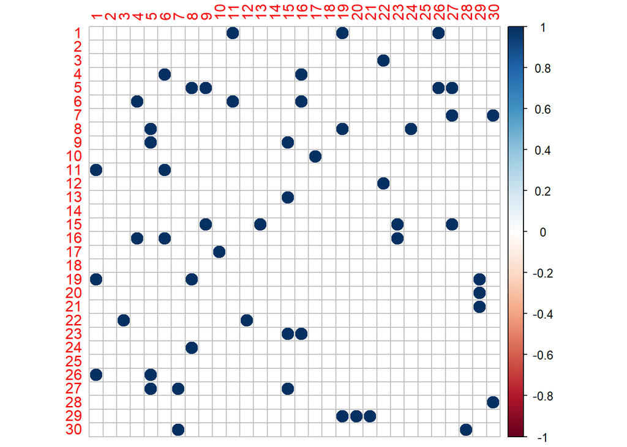

```r
# Génération des données
X = mvrnorm(n=n,mu=rep(0,p),Sigma=Sigma)

# Estimation par GLASSO avec lambda_ast
glasso.res = huge(x = X, method = "glasso",lambda = lambda_ast,verbose = F)
hatA_lambda_ast = glasso.res$path[[1]]

library(corrplot)
corrplot(hatA_lambda_ast)
```

```r
# Procédure de validation croisée
library(CVglasso)
CVglasso.res = CVglasso(X = X, K = 20, nlam = 1000,trace = "none") # Je m'arret là pour cause de temps de calcul
hat_lambda = CVglasso.res$Tuning
print(hat_lambda)
```

```
##      log10(lam)        lam
## [1,]  -1.980981 0.01044765
```

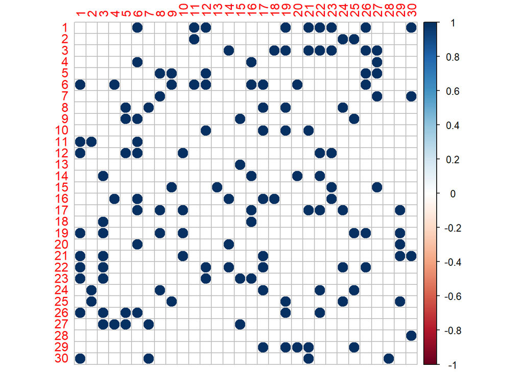

```r
hatK_LASSO_CV = CVglasso.res$Omega

hatA_hatlambda <- hatK_LASSO_CV

hatA_hatlambda[abs(hatK_LASSO_CV) > 0] <- 1
diag(hatA_hatlambda) <- 0
corrplot(hatA_hatlambda)
```

#### Quel est le meilleur estimateur entre $\hat{A}_{\lambda^\ast}$ et $\hat{A}_{\hat{\lambda}}$ pour l’erreur de Frobenius ?

```r
if (sum(diag(t(A)%*%hatA_lambda_ast)) < sum(diag(t(A)%*%hatA_hatlambda))) {
  print("C'est le GLASSO par Monte-Carlo")
}else{
  print("C'est le GLASSO par Validation croisée")
}
```

```
## [1] "C'est le GLASSO par Monte-Carlo"
```

## Question 9 - 2 pts

#### Compléter le code ci-dessous pour implémenter un choix du seuil dans la procédure de tests d’hypothèses à l’aide la méthode FDR de Benjamini-Hochberg au seuil 5% (taux de détection de faux positifs) et en déduire un nouvel estimateur de la matrice d’adjacence $A$

```r
alpha_FDR = 0.05

alpha_FDR <- p.adjust(p = p_value, method = "BH") # Cette fonction nousn donne directement la p_valeur corrigé en utilisant la méthode de BH = Benjamini Hockberg

# La Matrice d'adjacence

hatA_alpha_FDR = matrix(0,p,p)

hatA_alpha_FDR[abs(p_value) < alpha_FDR] <- 1

diag(hatA_alpha_FDR) <- 0
```

#### Compléter le code ci-dessous pour déterminer la meilleure des procédures en terme d’erreur de Frobenius entre les estimateurs $\hat{A}_{\lambda^\ast}$, $\hat{A}_{\hat{\lambda}}$ et celui donné par la méthode FDR.

```r
if (sum(diag(t(A)%*%hatA_lambda_ast)) < sum(diag(t(A)%*%hatA_hatlambda)) &

              sum(diag(t(A)%*%hatA_lambda_ast)) < sum(diag(t(A)%*%hatA_alpha_FDR))) {

  print("C'est le GLASSO par Monte-Carlo")

}else if (sum(diag(t(A)%*%hatA_hatlambda)) < sum(diag(t(A)%*%hatA_alpha_FDR)) &

          sum(diag(t(A)%*%hatA_hatlambda)) < sum(diag(t(A)%*%hatA_lambda_ast))) {

  print("C'est le GLASSO par Validation croisée")

}else if (sum(diag(t(A)%*%hatA_alpha_FDR )) < sum(diag(t(A)%*%hatA_hatlambda))
          &
            sum(diag(t(A)%*%hatA_alpha_FDR )) < sum(diag(t(A)%*%hatA_lambda_ast)))
  {
  print("C'est la méthode FDR")
}
```

```
## [1] "C'est le GLASSO par Monte-Carlo"
```